# 24-Year AMR Trends in *Salmonella* Typhi, Bangladesh

Reproducing and extending Tanmoy et al. 2024 (CHRF) | CHRF Portfolio

Author

Md Abrar Faiyaj

Published

June 6, 2026

## Background and Biological Question

A landmark 2024 CHRF study by Tanmoy et al. provided the most comprehensive picture of these dynamics, tracking 12,435 isolates over 24 years. Their central finding was paradoxical: **MDR is declining** — yet **newer antibiotics face rising or entrenched resistance**, potentially closing the window for effective oral typhoid treatment.

**Biological question addressed here:**

> *Does declining MDR in Bangladesh reflect genuine clinical progress, or does it mask a growing resistance burden for the limited antibiotics that remain?*

## Data Sources

**Primary:** Tanmoy AM et al. (2024). *PLOS Neglected Tropical Diseases* 18(10): e0012558. Supplementary Data S1. 12,435 individual culture-confirmed *S.* Typhi isolates from CHRF surveillance, Dhaka, 1999–2022. Phenotypic resistance (R/S/I) by CLSI breakpoints. Annual resistance rates calculated from raw isolate-level data.

**Secondary:** TyphiNET Database (typhinet.org). Dashboard-quality whole-genome sequencing (WGS) data for *S.* Typhi isolates globally. Used here for 1,664 Bangladesh WGS isolates and South Asian regional comparison (Bangladesh, Pakistan, India, Nepal). Provides genotype assignments, AMR determinant profiles (gyrA, parC, acrB mutations), and ciprofloxacin resistance classification (CipNS, CipR, XDR).

## Methods

**Trend analysis:** Linear regression (`lm(pct_resistant ~ year)`) applied to each antibiotic independently. Slope = percentage-point change per surveillance year. Statistical significance threshold: p < 0.05. R² reported as measure of linear fit.

**Period summary:** Annual resistance rates grouped into five predefined surveillance periods (1999–2004, 2005–2009, 2010–2014, 2015–2018, 2019–2022). Mean resistance rate calculated per period.

**Genomic validation:** TyphiNET isolates filtered to “Include” (dashboard-quality) classification. Ciprofloxacin non-susceptibility (CipNS) and full resistance (CipR) trends analysed by year. Fluoroquinolone resistance mutation prevalence (gyrA S83F, gyrA S83Y, gyrA D87N, parC E84K, acrB R717Q) calculated across all Bangladesh WGS isolates. South Asian XDR comparison across Bangladesh, Pakistan, India, Nepal.

All analysis performed in R ≥ 4.3 (tidyverse); reproducible via renv.

## Results

```r
library(tidyverse)
library(here)
library(kableExtra)

bangladesh <- readRDS(here("data","processed","bangladesh_amr.rds"))
trend_res  <- read_csv(here("results","trend_regression.csv"),  show_col_types = FALSE)
period_sum <- read_csv(here("results","period_summary.csv"),    show_col_types = FALSE)

bd_genomic <- readRDS(here("data","processed","bd_genomic.rds"))
sa_genomic <- readRDS(here("data","processed","sa_genomic.rds"))
```

### Figure 1: The central AMR paradox

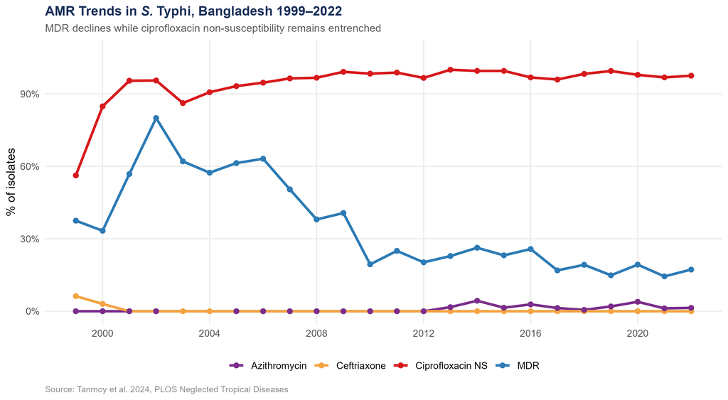

AMR trends in *S.* Typhi, Bangladesh 1999–2022

```r
knitr::include_graphics(here("figures","fig1_amr_trends.png"))
```

### Figure 2: Diverging AMR trajectories by drug class

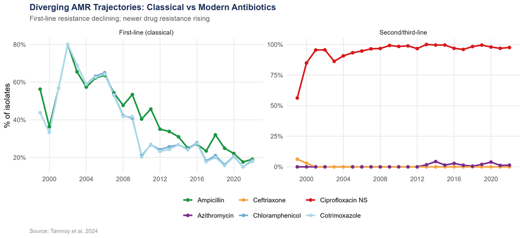

Classical vs modern antibiotic resistance divergence

```r
knitr::include_graphics(here("figures","fig2_drug_class_divergence.png"))
```

### Figure 3: AMR prevalence by surveillance era

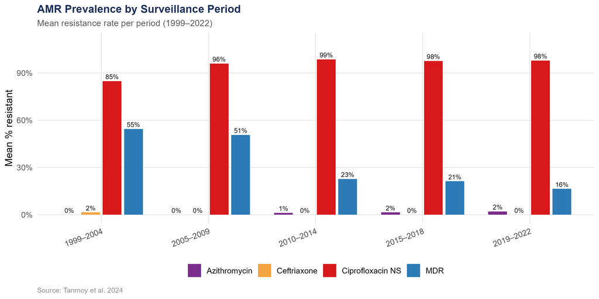

Mean resistance rates per 5-year surveillance period

```r
knitr::include_graphics(here("figures","fig3_period_summary.png"))
```

### Trend regression summary

```r
trend_res %>%
  select(
    Antibiotic     = antibiotic,
    `Slope (%/yr)` = slope_pct_per_year,
    R2             = r_squared,
    `P-value`      = p_value,
    Direction      = direction,
    Significant    = significant
  ) %>%
  kbl(caption = "Table 1. Linear trend regression for AMR rates, Bangladesh 1999–2022") %>%
  kable_styling(bootstrap_options = c("striped","hover","condensed")) %>%
  row_spec(which(trend_res$significant == "Yes"), bold = TRUE)
```

Table 1. Linear trend regression for AMR rates, Bangladesh 1999–2022

| Antibiotic | Slope (%/yr) | R2 | P-value | Direction | Significant |
| --- | --- | --- | --- | --- | --- |
| MDR | -2.13 | 0.616 | 0.0000 | Decreasing ↓ | Yes |
| Ciprofloxacin NS | 0.73 | 0.329 | 0.0034 | Increasing ↑ | Yes |
| Ceftriaxone | -0.09 | 0.209 | 0.0246 | Decreasing ↓ | Yes |
| Azithromycin | 0.12 | 0.395 | 0.0017 | Increasing ↑ | Yes |
| Ampicillin | -2.09 | 0.728 | 0.0000 | Decreasing ↓ | Yes |
| Chloramphenicol | -2.20 | 0.637 | 0.0000 | Decreasing ↓ | Yes |
| Cotrimoxazole | -2.22 | 0.641 | 0.0000 | Decreasing ↓ | Yes |

### Period summary

```r
period_sum %>%
  kbl(caption = "Table 2. Mean AMR rates by 5-year surveillance period") %>%
  kable_styling(bootstrap_options = c("striped","hover","condensed"))
```

Table 2. Mean AMR rates by 5-year surveillance period

| period | n_isolates | mean_mdr | mean_cip_ns | mean_cef | mean_azi |
| --- | --- | --- | --- | --- | --- |
| 1999–2004 | 296 | 54.5 | 84.8 | 1.5 | 0.0 |
| 2005–2009 | 2985 | 50.7 | 96.0 | 0.0 | 0.0 |
| 2010–2014 | 1225 | 22.8 | 98.7 | 0.0 | 1.2 |
| 2015–2018 | 4009 | 21.3 | 97.7 | 0.0 | 1.5 |
| 2019–2022 | 3920 | 16.5 | 97.9 | 0.0 | 2.1 |

## Genomic Validation: TyphiNET Database

The phenotypic trends above describe *what* resistance looks like in culture. The TyphiNET WGS data below explains *why* — the specific mutations encoding that resistance, and where Bangladesh stands relative to its regional neighbours.

### Figure 4: South Asia genomic AMR profile

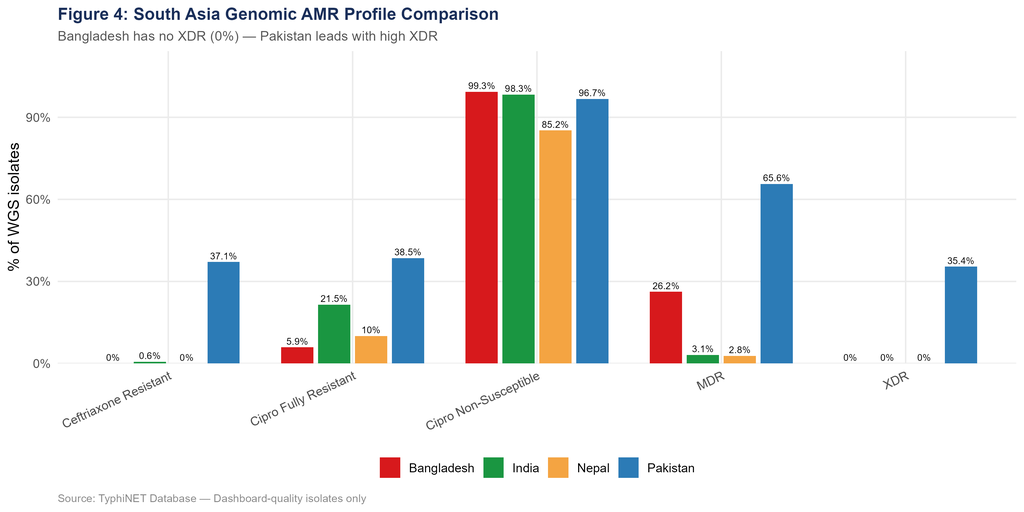

South Asia genomic AMR comparison (TyphiNET)

```r
knitr::include_graphics(here("figures","fig4_south_asia_genomic.png"))
```

**Figure 4.** Country-level genomic AMR comparison from TyphiNET WGS data (Bangladesh, Pakistan, India, Nepal). The critical finding: Bangladesh has **0% XDR** while Pakistan is at **35.4% XDR**. Pakistan’s XDR outbreak of 2016–2019 arose from a trajectory that Bangladesh currently mirrors in ciprofloxacin resistance accumulation. Bangladesh is at the inflection point — not past it. The window to act remains open.

### Figure 5: The molecular mechanism of ciprofloxacin resistance

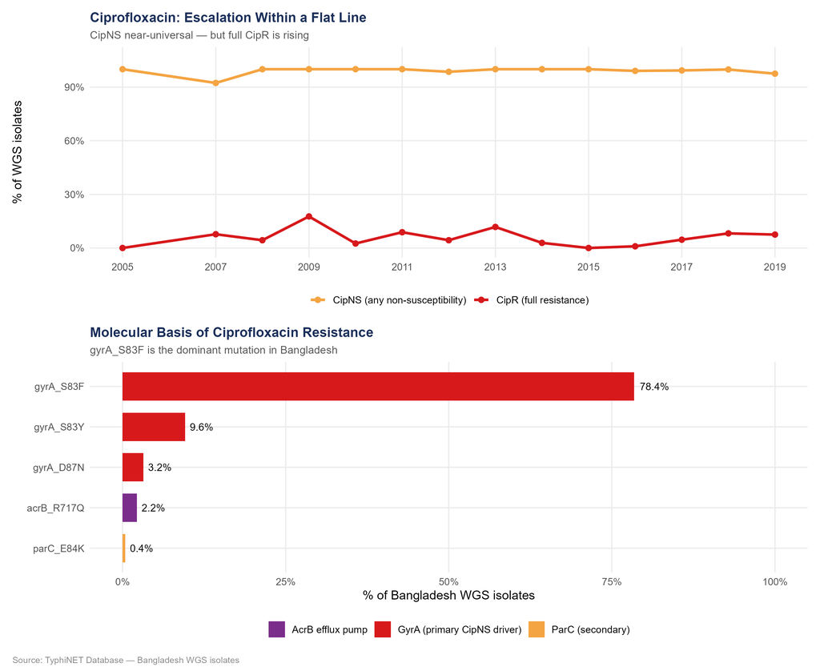

CipR escalation and gyrA mutation landscape (TyphiNET Bangladesh)

```r
knitr::include_graphics(here("figures","fig5_genomic_mechanism.png"))
```

**Figure 5.** Two panels from TyphiNET Bangladesh WGS data. **Top:** Although CipNS has been near-universal throughout the surveillance period, *full* ciprofloxacin resistance (CipR) is rising — from 0.9% (2016) to 8.2% (2018). The bacteria are accumulating a second resistance mutation on top of the first; the flat CipNS line conceals an escalating molecular process. **Bottom:** gyrA S83F alone is present in 78% of all Bangladesh WGS isolates — a single mutation that has swept through the population and explains the near-universal non-susceptibility observed phenotypically in the Tanmoy surveillance data.

### Genomic summary statistics

```r
bd_genomic %>%
  summarise(
    `Total WGS isolates (Bangladesh)` = as.character(n()),
    `Year range` = paste(min(year, na.rm=TRUE), "–", max(year, na.rm=TRUE)),
    `% CipNS`    = paste0(round(mean(cip_ns, na.rm=TRUE)*100, 1), "%"),
    `% CipR (full)` = paste0(round(mean(cip_r,  na.rm=TRUE)*100, 1), "%"),
    `% XDR`      = paste0(round(mean(is_xdr, na.rm=TRUE)*100, 1), "%"),
    `% H58 lineage (4.3.1)` = paste0(round(mean(is_H58, na.rm=TRUE)*100, 1), "%")
  ) %>%
  pivot_longer(everything(), names_to = "Metric", values_to = "Value") %>%
  kbl(caption = "Table 3. Bangladesh WGS isolate summary (TyphiNET)") %>%
  kable_styling(bootstrap_options = c("striped","hover","condensed"), full_width = FALSE)
```

Table 3. Bangladesh WGS isolate summary (TyphiNET)

| Metric | Value |
| --- | --- |
| Total WGS isolates (Bangladesh) | 1664 |
| Year range | 2000 – 2019 |
| % CipNS | 99.3% |
| % CipR (full) | 5.9% |
| % XDR | 0% |
| % H58 lineage (4.3.1) | 43.4% |

## Discussion

The TyphiNET genomic data adds mechanistic resolution to this picture. The near-universal ciprofloxacin non-susceptibility seen in culture is explained by a single mutation — gyrA S83F — present in 78% of Bangladesh WGS isolates. This mutation has effectively fixed itself in the Bangladesh *S.* Typhi population. What the phenotypic time series shows as a flat line near 100%, the genomic data reveals as a sweep. Furthermore, CipR (full resistance, typically requiring a second mutation) is now rising, suggesting the population is not static but continuing to accumulate resistance determinants.

The South Asian comparison is the most urgent finding. Bangladesh currently has 0% XDR; Pakistan reached 35.4% following a well-documented 2016–2019 outbreak that arose from exactly the AMR accumulation trajectory Bangladesh is now on. The difference between the two countries is not biology — it is time.

**The evidence-based response is already underway.** On 12 October 2025, Bangladesh launched a nationwide Typhoid Conjugate Vaccine campaign covering 50 million children, projected to prevent 6,000 deaths per year. The data in this repository is the scientific argument that informed that decision.

## Reproducibility

Full code, renv lockfile, and training notes: `https://github.com/mdabrarfaiyaj/Typoid-Fever-in-Bangladesh`

Live report: `https://mdabrarfaiyaj.github.io/Typoid-Fever-in-Bangladesh`

## References

1. Tanmoy AM, Hooda Y, Sajib MSI et al. (2024). Trends in antimicrobial resistance amongst *Salmonella* Typhi in Bangladesh: A 24-year retrospective observational study (1999–2022). *PLOS Neglected Tropical Diseases* 18(10): e0012558. https://doi.org/10.1371/journal.pntd.0012558
2. TyphiNET Database. Wellcome Sanger Institute and global collaborators. Whole-genome sequencing surveillance of *Salmonella* Typhi. https://www.typhinet.org
3. Tanmoy AM et al. (2018). *Salmonella* Typhi in Bangladesh: Genomic Diversity and Antimicrobial Resistance. *mBio* 9(6): e02112-18.
4. Government of Bangladesh, UNICEF, Gavi, WHO (2025). Bangladesh launches nationwide Typhoid Conjugate Vaccine campaign to protect 50 million children. Campaign launch: 12 October 2025.